# EX02: Control of the automatic nervous system under alcohol

The objective of this exercice is to analyse the control of the autonomic  
nervous system at rest and after alcool consumption using breathing, mean  
blood pressure and interbeat signals.

```python
import numpy as np
import pylab as py
py.ion()
py.close('all')
import scipy.signal as sp
import m03_ex2_ext as my_plot
```

Load signals of a subject at rest.

```python
x = np.genfromtxt('heart_1.dat', delimiter='  ').T
x = {'rr':x[0], 'bp':x[1], 'resp':x[2]}
# Load signals of a subject after alcool consumption.
y = np.genfromtxt('heart_2.dat', delimiter='  ').T
y = {'rr':y[0], 'bp':y[1], 'resp':y[2]}
# Signals are sampled at 4 Hz.
fs = 4
# Generate the time for the recordings.
t = np.arange(len(x['rr']))/fs
```

Cardiac interbeats, mean blood pressure and respiration volume of a subject  
at rest.

Q: Comment the different signals and their realtionships.

The respiratory signal presents a high-frequency oscillation. The cardiac interbeat interval follows this rhythm but with smaller fluctuations. The mean blood pressure varies more slowly, showing broader oscillations that are partly influenced by both respiration and heart rate changes. Together, the signals illustrate the combined effects of breathing on heart rhythm and blood pressure regulation.

Q: Which signals are related and how?

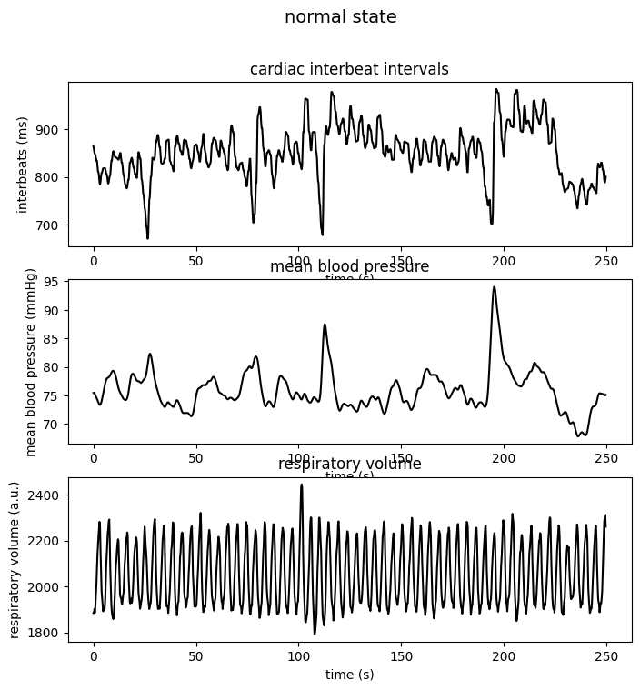

```python
my_plot.plot_time(x, t, 'normal state')
```

Cardiac interbeats, mean blood pressure and respiration volume of a subject  
after alcool consumption.  
Q: Comment the different signals and their realtionships.

Q: Which signals are related and how?

Respiration still influences the cardiac interbeat interval, but the link is weaker than with no alcohol consumption. Blood pressure and the cardiac interbeat interval remain connected through the reflex that stabilizes pressure, yet this interaction is less efficient and less visible.

Q: What are the differences with rest recording of previous figure?

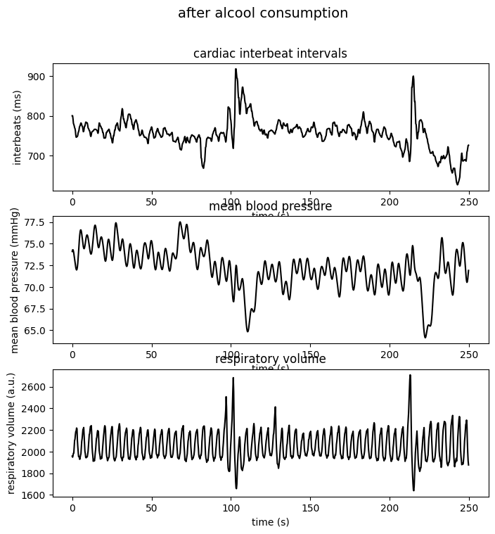

```python
my_plot.plot_time(y, t, 'after alcool consumption')
```

Compute the intercorrelation of the signals of the subject at rest.  
Q: Comment the oscillation present in the different signals.

The breathing autocorrelation plot show a symetric linearly decading signal. Wich is kind of normal as the respiratory signal act like a sinusoide with almost same amplitude leading to a non random signal. The cardiac interbeat show a slow frequency signal with little high frequency modulation. The fast component is due to the constant regulation of the blood pressure while the slow component are due to extreme case of high/low blood pressure. The blood pressure autocorrelation just show slow fluctuations that are due to change of blood pressure

Q: Which signals are related and how.

The cardiac interbeat signal is correlated with the mean blood pressure signals as explained above

```python
def my_corr(x):
    rxx = np.correlate(x-np.mean(x), x-np.mean(x), mode='full')/len(x)
    return rxx
```

```python
x['rxx_rr'] = my_corr(x['rr'])
x['rxx_bp'] = my_corr(x['bp'])
x['rxx_resp'] = my_corr(x['resp'])
```

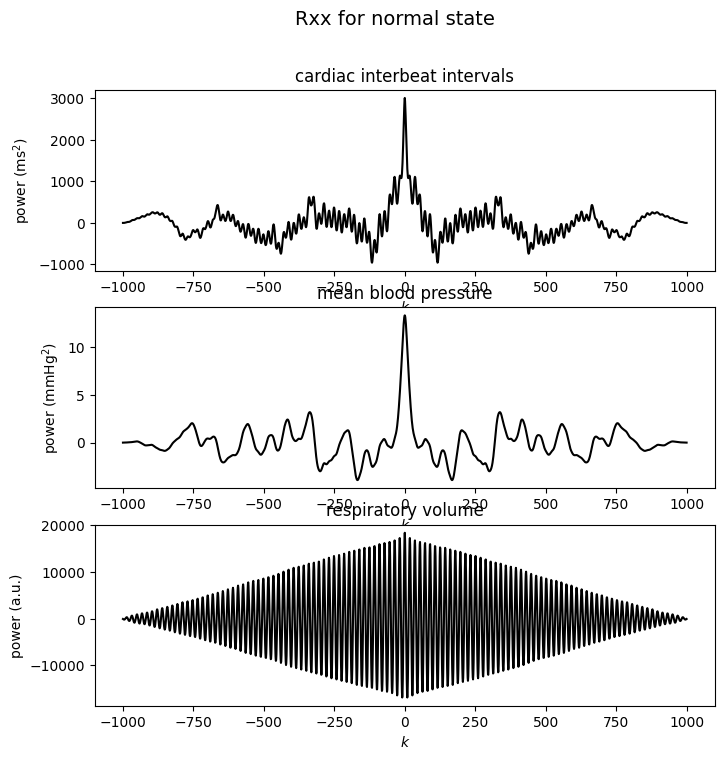

```python
my_plot.plot_rxx(x, 'Rxx for normal state')
```

Compute the intercorrelation of the signals of the subject after alcool  
consumption.

Q: Comment the oscillation present in the different signals.

Respiration shows a very strong and regular oscillation, visible as repeated peaks in the autocorrelation. The interbeat intervals present a central peak with smaller side oscillations, indicating irregular variability with some periodic components. Mean blood pressure displays a central peak with superimposed fast oscillations, reflecting smaller and less stable rhythmicity.

Q: Which signals are related and how.

Q: What difference do you observe with the previous figure?

Compared with the resting state, the autocorrelations after alcohol show reduced amplitude and less regular oscillatory patterns, especially in interbeat intervals and mean blood pressure. This indicates a weakening of the autonomic modulation, with respiration remaining regular but its influence on cardiovascular signals diminished.

```python
y['rxx_rr'] = my_corr(y['rr'])
y['rxx_bp'] = my_corr(y['bp'])
y['rxx_resp'] = my_corr(y['resp'])
```

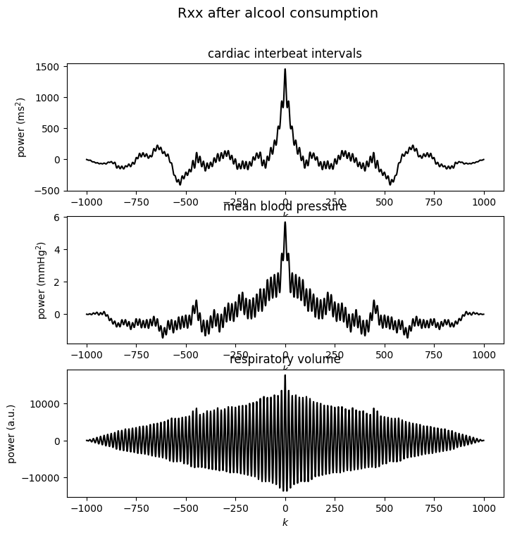

```python
my_plot.plot_rxx(y, 'Rxx after alcool consumption')
```

Compute the PSD of the signal for the subject at rest.  
Q: How the different peaks are related to the control of the autonomic  
nervous system?

The sharp peak of respiration (0.20–0.25 Hz, HF band) marks respiratory sinus arrhythmia and vagal (parasympathetic) modulation; the LF peak in cardiac intervals and blood pressure (~0.1 Hz) reflects baroreflex-driven oscillations (“Mayer waves”) with mixed sympathetic–parasympathetic influence; the very-low-frequency background in blood pressure (<0.04 Hz) reflects slower regulatory mechanisms.

Q: Do the positions and amplitude of the peaks confirm you previous  
findings;

```python
from scipy.signal import windows
def my_psd(x, half_win=250):
    interval = np.arange(-half_win,half_win+1)+len(x)//2
    x_sub = x[interval]
    psd = np.abs(np.fft.fft(windows.hann(len(interval))*x_sub, 2048))
    return psd
```

```python
x['RR'] = my_psd(x['rxx_rr'])
x['BP'] = my_psd(x['rxx_bp'])
x['RESP'] = my_psd(x['rxx_resp'])
```

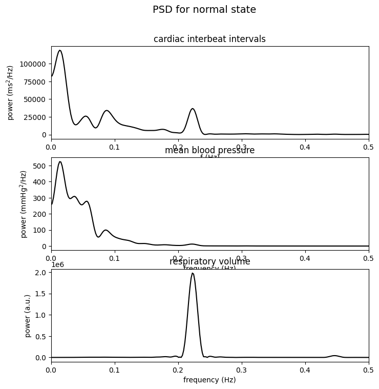

```python
my_plot.plot_X(x, fs, 'PSD for normal state')
```

Compute the PSD of the signal for the subject after alcool consumption.  
Q: How the different peaks are related to the control of the autonomic  
nervous system?

The spectrum shows a clear respiratory peak around 0.2 Hz in the breathing signal, while in the interbeat intervals and blood pressure this peak is smaller, reflecting a weaker modulation of cardiovascular activity by respiration. Low-frequency components are still visible, mainly in blood pressure, indicating ongoing baroreflex and sympathetic activity.

Q: Do the positions and amplitude of the peaks confirm you previous  
findings;

Yes. The respiratory peak appears consistently at the expected frequency, confirming the link between breathing and autonomic modulation. Its reduced amplitude in interbeat intervals and blood pressure supports the observation that autonomic influence on these signals is less pronounced, while blood pressure continues to display stronger low-frequency power.

```python
y['RR'] = my_psd(y['rxx_rr'])
y['BP'] = my_psd(y['rxx_bp'])
y['RESP'] = my_psd(y['rxx_resp'])
```

```python
my_plot.plot_X(y, fs, 'PSD after alcool consumption')
```

[output not shown]

Plot the PSDs of the signals for the two conditions.  
Q: Discuss the differences.

Breathing peaks at the same frequency (~0.22–0.25 Hz) in both conditions, with only a slight reduction in amplitude after alcohol. In the cardiac interbeat intervals, the high-frequency peak at the respiratory rate is strong at rest but largely suppressed after alcohol, indicating weaker respiratory sinus arrhythmia. Mean blood pressure shows reduced low-frequency power (<0.15 Hz) and a more evident high-frequency peak at the respiratory rate. Overall, spectral power in cardiovascular signals is lower after alcohol, especially in the LF and HF components, pointing to diminished autonomic modulation, with respiration remaining regular but exerting less influence on heart rate and blood pressure.

```python
my_plot.plot_XY(x, y, fs, 'Comparison of the PSD')
```

[output not shown]